# DS2 Homework 1 Solution

Cosmin Catalin Ticu

3/18/2021

# GitHub repo [here](https://github.com/cosmin-ticu/DS2_Ensemble-Stacking)

# 1. Tree Ensemble Models

Let’s take a look at the required packages for this part of the assignment and inspect the data. Looking at the target variable, we can see its binary distribution.

```r
library(tidyverse)
library(caret)
library(rpart.plot)
library(gbm)
library(xgboost)
library(caTools)
library(pROC)
library(viridis)

data <- as_tibble(ISLR::OJ)

table(data$Purchase)
```

```
##
##  CH  MM
## 653 417
```

## a. Create a training data of 75% and keep 25% of the data as a test set. Train a decision tree as a benchmark model. Plot the final model and interpret the result (using rpart and rpart.plot is an easier option).

The data was split into training and test samples and a benchmark tree model was ran using all of the default options in caret package. Another option for building this model would have been to just have a single split tree. Nonetheless, it is more interesting to inspect and visualize a fully grown tree with the default settings.

```r
# a. ----------------------------------------------------------------------


# Work vs holdout sets
set.seed(1234)
train_indices <- as.integer(createDataPartition(data$Purchase,
                                                p = 0.75, list = FALSE))
data_train <- data[train_indices, ]
data_holdout <- data[-train_indices, ]

fitControl <- trainControl(method = "cv", number = 5,
                           summaryFunction = twoClassSummary,
                           classProbs=TRUE,
                           verboseIter = F,
                           savePredictions = TRUE)
set.seed(1234)
model_tree_benchmark<-train(
  Purchase~.,
  data=data_train,
  method="rpart",
  trControl=fitControl
)

# look at the model summary statistics & details
model_tree_benchmark
```

```
## CART
##
## 803 samples
##  17 predictor
##   2 classes: 'CH', 'MM'
##
## No pre-processing
## Resampling: Cross-Validated (5 fold)
## Summary of sample sizes: 642, 643, 643, 642, 642
## Resampling results across tuning parameters:
##
##   cp          ROC        Sens       Spec
##   0.02236422  0.8469458  0.8204082  0.8020481
##   0.04153355  0.7855954  0.8122449  0.7380440
##   0.46006390  0.7142199  0.8653061  0.5631336
##
## ROC was used to select the optimal model using the largest value.
## The final value used for the model was cp = 0.02236422.
```

Plotting the decision tree performance (ROC) according to its complexity parameter, we see:

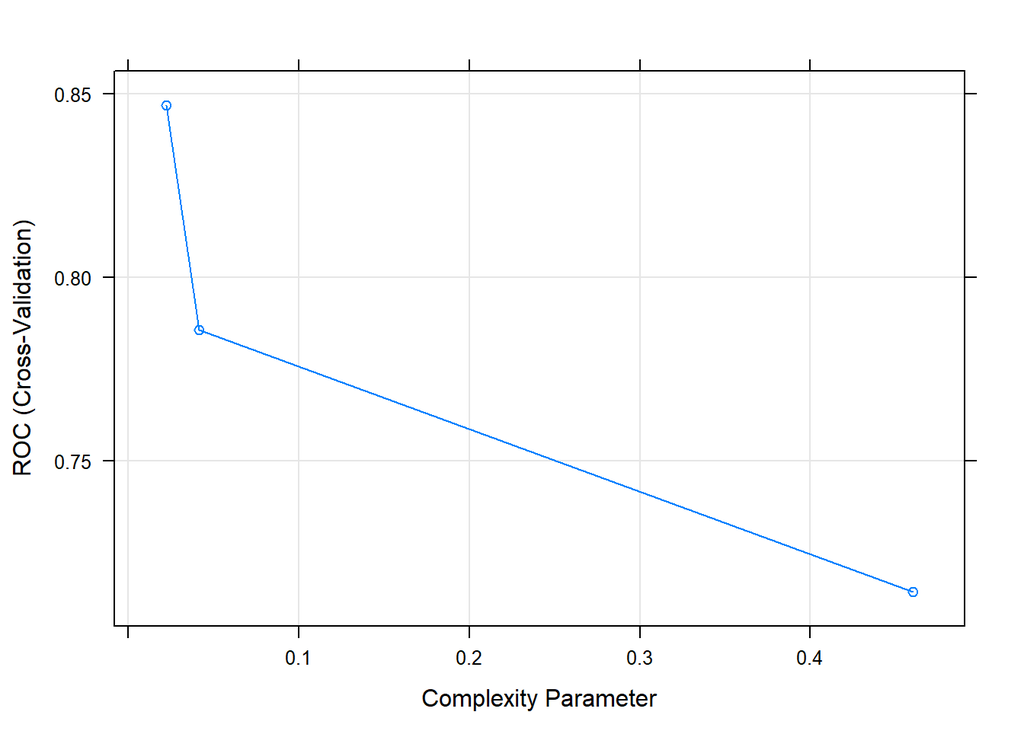

```r
# plot the decision tree
plot(model_tree_benchmark)
```

In the case of the default decision tree, it is worthwhile to stick with the smallest complexity parameter, meaning that the overall larger tree is preferred as it achieves a better accuracy.

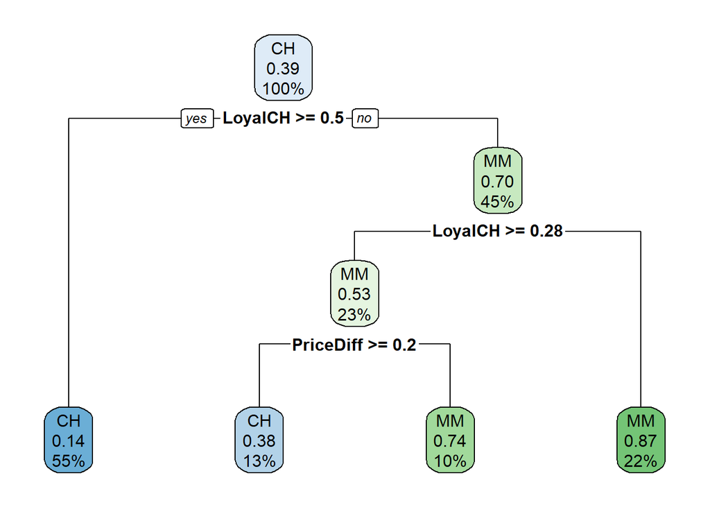

```r
# plot it looking nicer for easier interpretation
rpart.plot(model_tree_benchmark$finalModel)
```

Looking at the RPART PLOT we can see that brand loyalty dominates orange juice decisions. Only once brand loyalty features have been exhausted, the price difference starts to make a significant change between brands.

## b. Investigate tree ensemble models: random forest, gradient boosting machine, XGBoost. Try various tuning parameter combinations and select the best model using cross-validation.

The following tree ensemble models are built: random forest, gradient boosting machine and XGBoost.

The explanations for all of the tweaked parameters can be found in the codes below. The best models were identified in writing next to the function called the model result.

```r
train_control <- trainControl(
  method = "cv",
  n = 5,
  classProbs = TRUE, # same as probability = TRUE in ranger
  summaryFunction = twoClassSummary,
  savePredictions = TRUE,
  verboseIter = F
)
```

The training parameters were set. We can now run the models

```r
## Probability Forest

tune_grid <- expand.grid(
  .mtry = c(2,3,4,5),
  .splitrule = "gini",
  .min.node.size = c(5, 10)
)


set.seed(1234)
model_rf <- train(Purchase~ .,
                  data = data_train,
                  method = "ranger",
                  trControl = train_control,
                  tuneGrid = tune_grid,
                  importance = "impurity"
)
model_rf # node size = 10 & mtry (variable selection) = 5
```

```
## Random Forest
##
## 803 samples
##  17 predictor
##   2 classes: 'CH', 'MM'
##
## No pre-processing
## Resampling: Cross-Validated (5 fold)
## Summary of sample sizes: 642, 643, 643, 642, 642
## Resampling results across tuning parameters:
##
##   mtry  min.node.size  ROC        Sens       Spec
##   2      5             0.8691103  0.8897959  0.7026626
##   2     10             0.8685460  0.8816327  0.6994880
##   3      5             0.8733748  0.8795918  0.7250384
##   3     10             0.8757631  0.8857143  0.7314900
##   4      5             0.8772276  0.8734694  0.7313364
##   4     10             0.8786383  0.8836735  0.7378392
##   5      5             0.8775724  0.8653061  0.7473118
##   5     10             0.8821306  0.8755102  0.7602151
##
## Tuning parameter 'splitrule' was held constant at a value of gini
## ROC was used to select the optimal model using the largest value.
## The final values used for the model were mtry = 5, splitrule = gini
##  and min.node.size = 10.
```

With a minimum node size of 10 observations and a random variable selection parameter of 5 variables, the RF model achieved a best ROC on the cross-validated sample of 0.8821306.

```r
## Gradient Boosting Machine

gbmGrid <-  expand.grid(interaction.depth = c(1, 3, 5, 7, 9),
                        n.trees = 500, # known standard for GBM (stabilizes later than RF)
                        shrinkage = c(0.005, 0.01),
                        n.minobsinnode = c(2,5)) # to check overfitting

set.seed(1234)
model_gbm <- train(Purchase~ .,
                   data = data_train,
                   method = "gbm",
                   trControl = train_control,
                   tuneGrid = gbmGrid,
                   verbose = F
)
model_gbm # 500 trees, 3 nodes, 0.01 shrinkage and 2 min observations per node
```

```
## Stochastic Gradient Boosting
##
## 803 samples
##  17 predictor
##   2 classes: 'CH', 'MM'
##
## No pre-processing
## Resampling: Cross-Validated (5 fold)
## Summary of sample sizes: 642, 643, 643, 642, 642
## Resampling results across tuning parameters:
##
##   shrinkage  interaction.depth  n.minobsinnode  ROC        Sens       Spec
##   0.005      1                  2               0.8842346  0.8612245  0.6868920
##   0.005      1                  5               0.8829974  0.8612245  0.6868920
##   0.005      3                  2               0.8981846  0.8714286  0.7793651
##   0.005      3                  5               0.8984177  0.8714286  0.7825909
##   0.005      5                  2               0.8991614  0.8816327  0.7858679
##   0.005      5                  5               0.8984681  0.8775510  0.7826421
##   0.005      7                  2               0.8983902  0.8775510  0.7859191
##   0.005      7                  5               0.8982967  0.8795918  0.7763441
##   0.005      9                  2               0.8972690  0.8775510  0.7795699
##   0.005      9                  5               0.8990224  0.8816327  0.7827445
##   0.010      1                  2               0.8929922  0.8734694  0.7476190
##   0.010      1                  5               0.8927819  0.8775510  0.7443932
##   0.010      3                  2               0.8998992  0.8734694  0.7858679
##   0.010      3                  5               0.8992492  0.8795918  0.7891961
##   0.010      5                  2               0.8985736  0.8795918  0.7923195
##   0.010      5                  5               0.8977758  0.8734694  0.7859703
##   0.010      7                  2               0.8963834  0.8693878  0.7859703
##   0.010      7                  5               0.8974148  0.8795918  0.7699437
##   0.010      9                  2               0.8925750  0.8673469  0.7667179
##   0.010      9                  5               0.8926544  0.8714286  0.7795699
##
## Tuning parameter 'n.trees' was held constant at a value of 500
## ROC was used to select the optimal model using the largest value.
## The final values used for the model were n.trees = 500, interaction.depth =
##  3, shrinkage = 0.01 and n.minobsinnode = 2.
```

With a maximum tree depth of 3, a shrinkage of 0.01 and 2 minimum observations per terminal node, the GBM model achieved a best ROC on the cross-validated sample of 0.8998992.

```r
## XGBoost

xgb_grid <- expand.grid(nrounds = 500, # boosting iterations
                        max_depth = c(1, 3, 5, 7, 9), # tree depth/ same as interaction.depth
                        eta = c(0.005, 0.01), # shrinkage (same params as GBM)
                        gamma = 0.01, # minimum loss reduction
                        colsample_bytree = c(0.3, 0.5, 0.7), # subsample ratio of columns (similar to mtry)
                        min_child_weight = 1, # similar to n.minobsinnode
                        subsample = c(0.5, 0.7)) # dataset subsample
set.seed(1234)
model_xgboost <- train(Purchase ~ .,
                       method = "xgbTree",
                       data = data_train,
                       trControl = train_control,
                       tuneGrid = xgb_grid)
model_xgboost # depth of 3, shrinkage of 0.01 (same GBM), column sample 70%, subsample of 70%
```

```
## eXtreme Gradient Boosting
##
## 803 samples
##  17 predictor
##   2 classes: 'CH', 'MM'
##
## No pre-processing
## Resampling: Cross-Validated (5 fold)
## Summary of sample sizes: 642, 643, 643, 642, 642
## Resampling results across tuning parameters:
##
##   eta    max_depth  colsample_bytree  subsample  ROC        Sens
##   0.005  1          0.3               0.5        0.8824880  0.8857143
##   0.005  1          0.3               0.7        0.8799113  0.8836735
##   0.005  1          0.5               0.5        0.8859928  0.8653061
##   0.005  1          0.5               0.7        0.8866229  0.8673469
##   0.005  1          0.7               0.5        0.8843916  0.8591837
##   0.005  1          0.7               0.7        0.8834130  0.8673469
##   0.005  3          0.3               0.5        0.8873408  0.8795918
##   0.005  3          0.3               0.7        0.8904548  0.8836735
##   0.005  3          0.5               0.5        0.8973855  0.8877551
##   0.005  3          0.5               0.7        0.8981569  0.8857143
##   0.005  3          0.7               0.5        0.8985741  0.8795918
##   0.005  3          0.7               0.7        0.8992696  0.8755102
##   0.005  5          0.3               0.5        0.8820778  0.8795918
##   0.005  5          0.3               0.7        0.8783037  0.8775510
##   0.005  5          0.5               0.5        0.8926696  0.8816327
##   0.005  5          0.5               0.7        0.8910682  0.8734694
##   0.005  5          0.7               0.5        0.8966859  0.8795918
##   0.005  5          0.7               0.7        0.8945714  0.8775510
##   0.005  7          0.3               0.5        0.8786968  0.8795918
##   0.005  7          0.3               0.7        0.8749114  0.8755102
##   0.005  7          0.5               0.5        0.8905300  0.8795918
##   0.005  7          0.5               0.7        0.8860952  0.8775510
##   0.005  7          0.7               0.5        0.8924324  0.8836735
##   0.005  7          0.7               0.7        0.8899297  0.8755102
##   0.005  9          0.3               0.5        0.8752840  0.8714286
##   0.005  9          0.3               0.7        0.8773122  0.8734694
##   0.005  9          0.5               0.5        0.8891632  0.8816327
##   0.005  9          0.5               0.7        0.8848266  0.8816327
```

[output cut: 88 more lines]

```
##   0.7376856
##   0.7540195
##   0.7568868
##   0.7602663
##   0.7602663
##
## Tuning parameter 'nrounds' was held constant at a value of 500
## Tuning
##  parameter 'gamma' was held constant at a value of 0.01
## Tuning
##  parameter 'min_child_weight' was held constant at a value of 1
## ROC was used to select the optimal model using the largest value.
## The final values used for the model were nrounds = 500, max_depth = 3, eta
##  = 0.01, gamma = 0.01, colsample_bytree = 0.7, min_child_weight = 1
##  and subsample = 0.7.
```

With a maximum tree depth of 3, a shrinkage of 0.01, a column resampling of 70% as well as a dataset resampling of 70%, the XGBoost model achieved a best ROC on the cross-validated sample of 0.9004744. This is our best model.

## c. Compare the performance of the different models (if you use caret you should consider using the resamples function). Make sure to set the same seed before model training for all 3 models so that your cross validation samples are the same. Is any of these giving significantly different predictive power than the others?

```r
# c. ----------------------------------------------------------------------

# get performance measures
resamples <- resamples(list("decision_tree_benchmark" = model_tree_benchmark,
                            "rf" = model_rf,
                            "gbm" = model_gbm,
                            "xgboost" = model_xgboost))
summary(resamples)
```

```
##
## Call:
## summary.resamples(object = resamples)
##
## Models: decision_tree_benchmark, rf, gbm, xgboost
## Number of resamples: 5
##
## ROC
##                              Min.   1st Qu.    Median      Mean   3rd Qu.
## decision_tree_benchmark 0.8206997 0.8222515 0.8381336 0.8469458 0.8455620
## rf                      0.8289993 0.8814383 0.8839697 0.8821306 0.8957726
## gbm                     0.8704740 0.8936801 0.8949627 0.8998992 0.9139132
## xgboost                 0.8704740 0.8956916 0.8963134 0.9004744 0.9109977
##                              Max. NA's
## decision_tree_benchmark 0.9080823    0
## rf                      0.9204730    0
## gbm                     0.9264658    0
## xgboost                 0.9288954    0
##
## Sens
##                              Min.   1st Qu.    Median      Mean   3rd Qu.
## decision_tree_benchmark 0.7551020 0.7551020 0.7653061 0.8204082 0.8979592
## rf                      0.8163265 0.8775510 0.8877551 0.8755102 0.8877551
## gbm                     0.8367347 0.8673469 0.8775510 0.8734694 0.8877551
## xgboost                 0.8367347 0.8673469 0.8775510 0.8816327 0.9081633
##                              Max. NA's
## decision_tree_benchmark 0.9285714    0
## rf                      0.9081633    0
## gbm                     0.8979592    0
## xgboost                 0.9183673    0
##
## Spec
##                              Min.   1st Qu.    Median      Mean   3rd Qu.
## decision_tree_benchmark 0.7619048 0.7619048 0.8064516 0.8020481 0.8387097
## rf                      0.7258065 0.7419355 0.7619048 0.7602151 0.7777778
## gbm                     0.7580645 0.7619048 0.7903226 0.7858679 0.8095238
## xgboost                 0.7777778 0.7903226 0.7903226 0.7891449 0.7936508
##                              Max. NA's
## decision_tree_benchmark 0.8412698    0
## rf                      0.7936508    0
## gbm                     0.8095238    0
## xgboost                 0.7936508    0
```

The boosting algorithms appear to achieve a slightly better performance than the random forest model. This follows industry standards. It is worthwhile to consider that with a much smaller tree size, the random forest would probably inch forward as the best model, as it boosting algorithms rely on very weak classifiers that are not evenly distributed while random forest relies on entirely randomly created trees (uncorrelated, thus unbiased) leading to more “complex” individual tress (more complex only than the mere stumps of the boosting algos).

Get a nicer looking comparison table of the resample performances

```r
# make it look nicer
logit_models <- list()
logit_models[["decision_tree_benchmark"]] <- model_tree_benchmark
logit_models[["RF"]] <- model_rf
logit_models[["GBM"]] <- model_gbm
logit_models[["XGBoost"]] <- model_xgboost

CV_AUC_folds <- list()

for (model_name in names(logit_models)) {

  auc <- list()
  model <- logit_models[[model_name]]
  for (fold in c("Fold1", "Fold2", "Fold3", "Fold4", "Fold5")) {
    cv_fold <-
      model$pred %>%
      filter(Resample == fold)

    roc_obj <- roc(cv_fold$obs, cv_fold$CH)
    auc[[fold]] <- as.numeric(roc_obj$auc)
  }

  CV_AUC_folds[[model_name]] <- data.frame("Resample" = names(auc),
                                           "AUC" = unlist(auc))
}

CV_AUC <- list()

for (model_name in names(logit_models)) {
  CV_AUC[[model_name]] <- mean(CV_AUC_folds[[model_name]]$AUC)
}

knitr::kable(as.data.frame(CV_AUC), caption = 'Cross-validated AUC for all 4 models')
```

Cross-validated AUC for all 4 models

| decision_tree_benchmark | RF | GBM | XGBoost |
| --- | --- | --- | --- |
| 0.8041392 | 0.8753257 | 0.8929458 | 0.8848066 |

## d. Choose the best model and plot ROC curve for the best model on the test set. Calculate and interpret AUC.

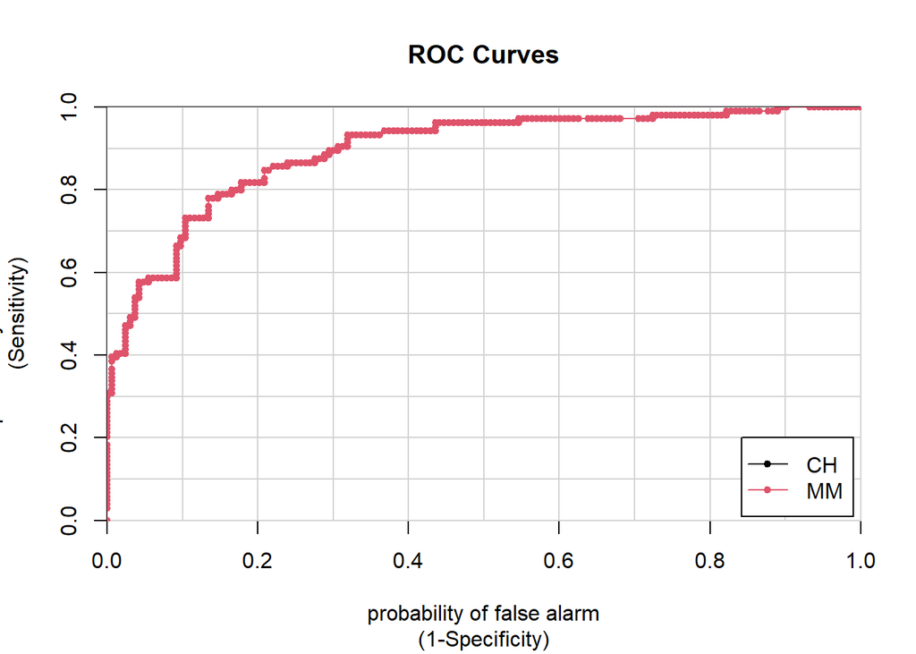

```
##                  CH        MM
## CH vs. MM 0.8948797 0.8948797
```

```r
# d. ----------------------------------------------------------------------

## ROC Plot with built-in package
gbm_pred<-predict(model_gbm, data_holdout, type="prob")
colAUC(gbm_pred, data_holdout$Purchase, plotROC = TRUE)
```

AUC for the GBM model is 89% which is really good. We will choose this one as the best model.

Plotting an ROC curve with own function looks a little nicer and allows later tweaking. AUC can be seen as highlighted region of plot (very good performance for a classification model).

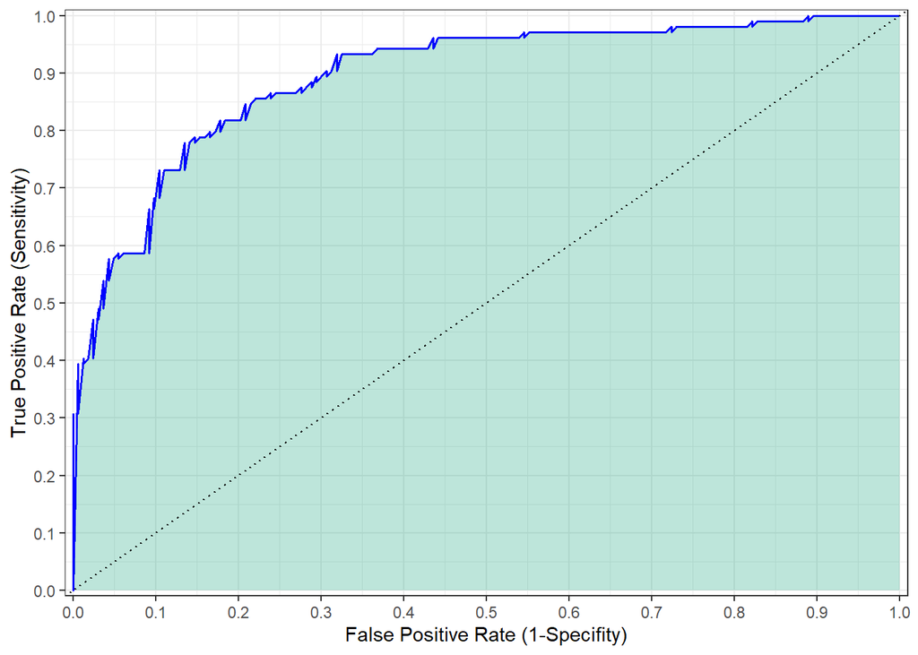

```r
## ROC plot with own function
data_holdout[,"best_model_no_loss_pred"] <- gbm_pred[,"CH"]

roc_obj_holdout <- roc(data_holdout$Purchase, data_holdout$best_model_no_loss_pred)

createRocPlot <- function(r, plot_name) {
  all_coords <- coords(r, x="all", ret="all", transpose = FALSE)

  roc_plot <- ggplot(data = all_coords, aes(x = fpr, y = tpr)) +
    geom_line(color='blue', size = 0.7) +
    geom_area(aes(fill = 'red', alpha=0.4), alpha = 0.3, position = 'identity', color = 'blue') +
    scale_fill_viridis(discrete = TRUE, begin=0.6, alpha=0.5, guide = FALSE) +
    xlab("False Positive Rate (1-Specifity)") +
    ylab("True Positive Rate (Sensitivity)") +
    geom_abline(intercept = 0, slope = 1,  linetype = "dotted", col = "black") +
    scale_y_continuous(limits = c(0, 1), breaks = seq(0, 1, .1), expand = c(0, 0.01)) +
    scale_x_continuous(limits = c(0, 1), breaks = seq(0, 1, .1), expand = c(0.01, 0)) +
    theme_bw()

  roc_plot
}

createRocPlot(roc_obj_holdout, "ROC curve for best model (GBM)")
```

## e. Inspect variable importance plots for the 3 models. Are similar variables found to be the most important for the 3 models?

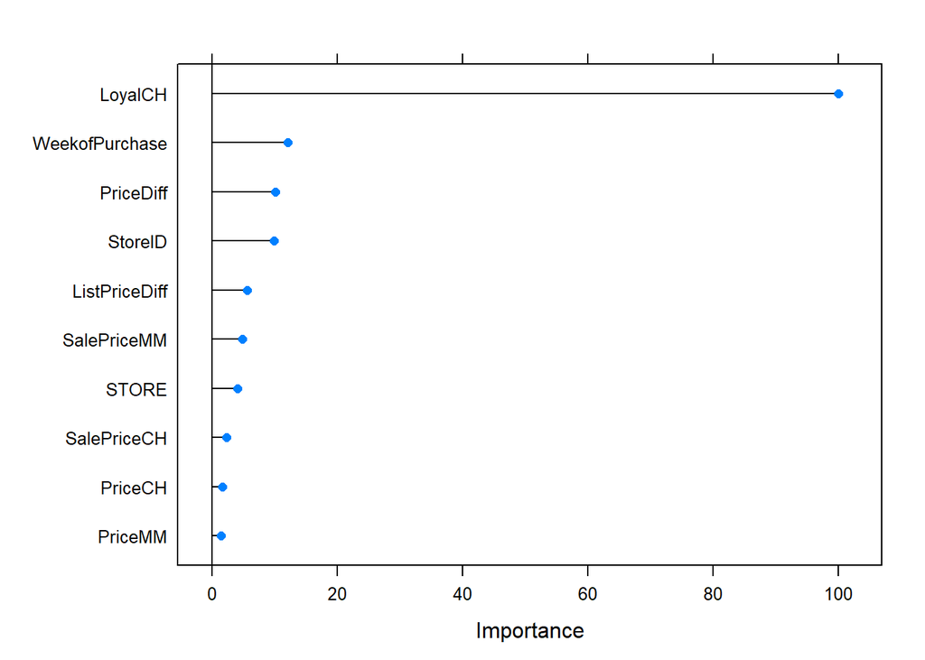

```r
plot(varImp(model_rf), top = 10)
```

Loyalty to the CH brand prevails. The rest of the variables mostly concern the price as the differentiating factor. Nonetheless, the difference in importance between the first variable and the rest is significant.

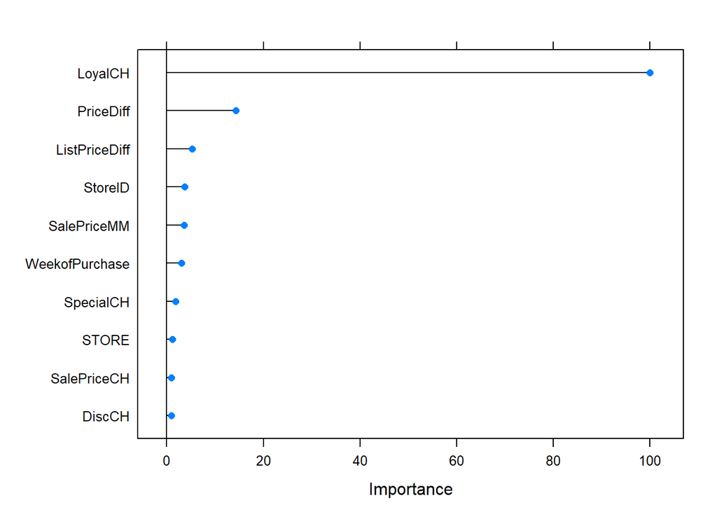

```r
plot(varImp(model_gbm), top = 10)
```

A notable change from the rf model, as that one is a bagged model, is that in the boosted models - Gradient Boosting Machine in this case, the rest of the variables (apart from LoyalCH) have a much lower importance. That is because boosted algorithms work with much simpler trees (stumps) within them and with shrinking parameters that ultimately penalize other variables each it is discovered that most of the variance can just be attributed to a variable as simple as brand loyalty. One could argue that the RF model, as a bagged model, allows for a better distribution of variables and a more equal inclusion in the models. For larger datasets, this could make RF and bagged models more robust overall. Thusm GBM is characterized by a more aggressive behavior of gradually drowning out variables.

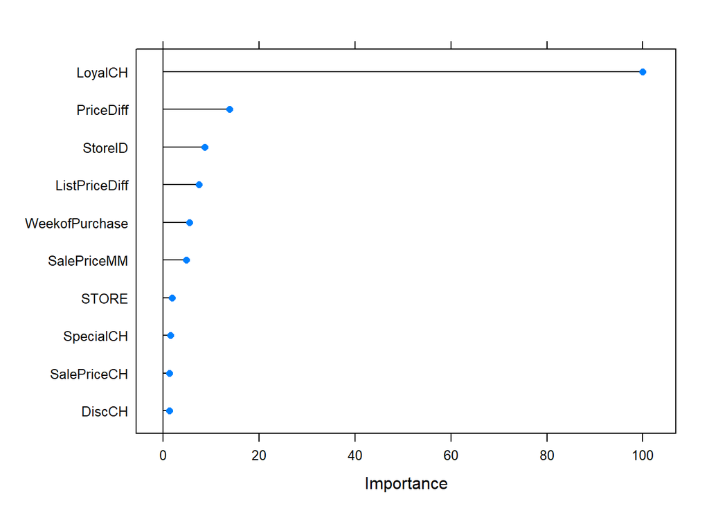

```r
plot(varImp(model_xgboost), top = 10)
```

# 2. Variable Importance Profiles

Load up the data and required packages.

```r
# clear memory
rm(list=ls())

library(tidyverse)
library(caret)
library(gbm)

df <- as_tibble(ISLR::Hitters) %>%
  drop_na(Salary) %>%
  mutate(log_salary = log(Salary), Salary = NULL)
```

## a. Train two random forest models: one with sampling 2 variables randomly for each split and one with 10 (use the whole dataset and don’t do cross-validation). Inspect variable importance profiles. What do you see in terms of how important the first few variables are relative to each other?

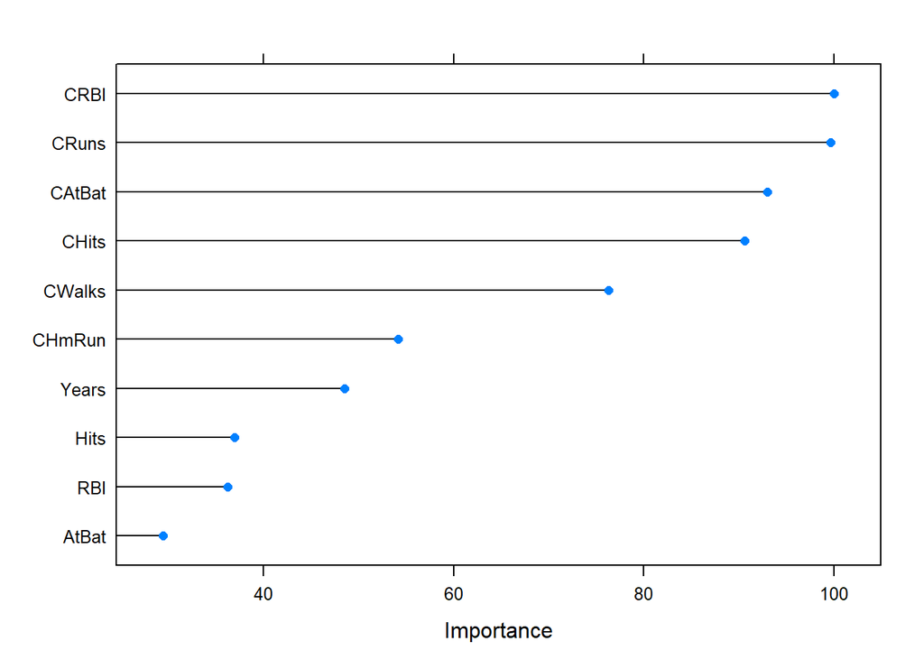

```r
# a. ----------------------------------------------------------------------

tune_grid <- expand.grid(
  .mtry = 2,
  .splitrule = "variance",
  .min.node.size = c(5, 10)
)
# random forest with 2 randomly sampled variables each time
set.seed(1234)
rf_model_2 <- train(log_salary ~ .,
                    method = "ranger",
                    data = df,
                    tuneGrid = tune_grid,
                    importance = "impurity"
)


tune_grid <- expand.grid(
  .mtry = 10,
  .splitrule = "variance",
  .min.node.size = c(5, 10)
)

# random forest with 10 randomly sampled variables each time
set.seed(1234)
rf_model_10 <- train(log_salary ~ .,
                    method = "ranger",
                    data = df,
                    tuneGrid = tune_grid,
                    importance = "impurity"
)

plot(varImp(rf_model_2), top=10)
```

```r
# much more balanced model as more "equal" shot are given to each variable
```

In the case of the variable importance plot for the random forest model with 2 variables, we can see that the distribution of importance is gradually decreasing as more “equal” shot are given to each variable.

## b. One of them is more extreme in terms of how the most important and the next ones relate to each other. Give an intuitive explanation how mtry/mtries relates to relative importance of variables in random forest models.

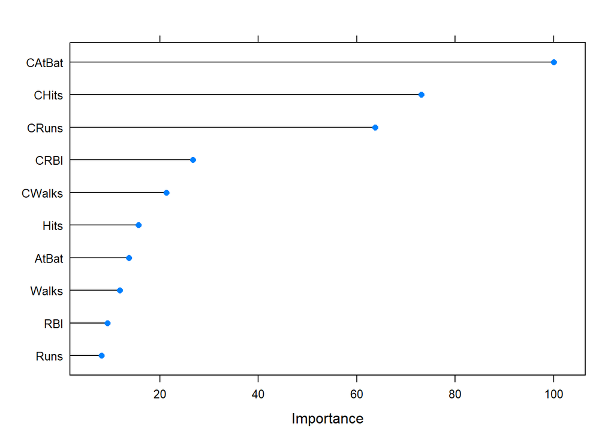

```r
plot(varImp(rf_model_10), top=10)
```

```r
# much more aggressive at the beginning
```

This is not the case when inspecting the random forest model with 10 variables subsampled with every tree. Not only does this increase the complexity of the model, but it penalizes certain variables early on, thus perpetuating their importance (or lack thereof) for the later stages. It is worthwhile to consider this type of algorithmic tuning, as it can yield drastically different results. If one is interested in identifying the truly top variable that explains the largest share of variance, then an aggressive model with a high mtry parameter should be used. However, if a more balanced model with hopes of predictive power needs to be identified, then using a lower mtry parameter seems to be the better choice.

It would be important to mention that tweaking the number of trees for the random forest model to a very high number would yield extremely close results between the two mtry-differing models (as variable importance would stablize in the long run).

## c. In the same vein, estimate two gbm models with varying rate of sampling for each tree (use 0.1 and 1 for the parameter bag.fraction/sample_rate). Hold all the other parameters fixed: grow 500 trees with maximum depths of 5, applying a learning rate of 0.1. Compare variable importance plots for the two models. Could you explain why is one variable importance profile more extreme than the other?

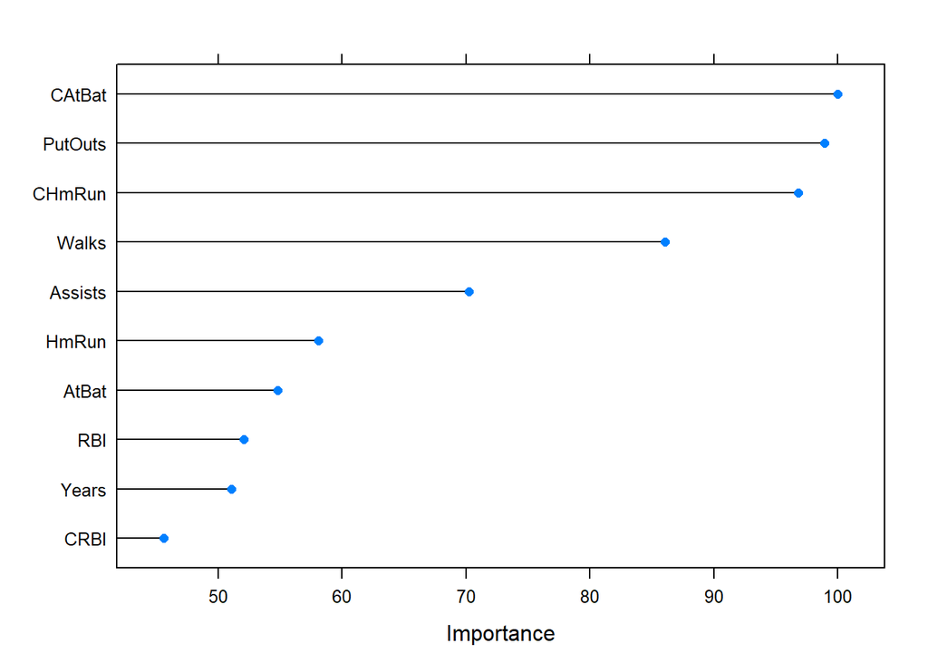

```r
gbm_grid <- expand.grid(n.trees = 500,
                        interaction.depth = 5, # maximum depth
                        shrinkage = 0.1,
                        n.minobsinnode = 5) # generic choice of 5 observations - not important in this case
set.seed(1234)
gbm_model_01_sample <- train(log_salary ~ .,
                      method = "gbm",
                      data = df,
                      bag.fraction=0.1,
                      tuneGrid = gbm_grid,
                      verbose = FALSE # gbm by default prints too much output
)

set.seed(1234)
gbm_model_full_sample <- train(log_salary ~ .,
                      method = "gbm",
                      data = df,
                      bag.fraction=1,
                      tuneGrid = gbm_grid,
                      verbose = FALSE # gbm by default prints too much output
)
plot(varImp(gbm_model_01_sample), top=10) # more balanced model
```

When examining the first variable importance plot for the GBM model with a subsampling parameter of 10%, we see a more even distribution of variable importance, following the same trend as the RF with a lower mtry parameter. Using only small chunks of the dataset allows for certain parts of the dataset to be better explained by certain variables. As an intuitive example, in the case of a random 10% subsample, we might only get data on a specific number of home runs, assists and walks, thus warranting that their associated variables appear more important for this respective dataset.

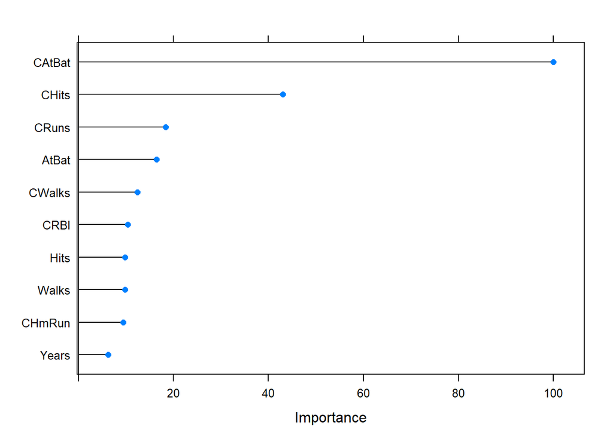

```r
plot(varImp(gbm_model_full_sample), top=10) # more aggressive from beginning
```

I would make an analogy of the GBM model with the full sample each time as a more aggressive model from the get-go. Using the entire dataset means that most of the trees behave similarly, thus reinforcing the findings of the initial very first tree. This can be summed up as using highly correlated trees to one-another. It is not worthwhile to run this algorithm with the full dataset, as it can easily overfit the data due to obvious and severe correlations between all the trees. With much too high correlations, we can expect the shrinkage function to not be as effective in giving weights to each tree, as they are all highly correlated. It has actually been proven in the industry that using an aggressive subsampling approach high reduces over-fitting, making the model more robust.

# 3. Stacking

This part of the assignment will leverage both the caret package and the h2o package.

Load up data and required packages. Launch an h2o instance of at least 4GB and at most 8GB for the interim computations.

```r
# clear memory
rm(list=ls())

library(tidyverse)
library(h2o)
library(caret)
library(caretEnsemble)
library(pROC)
library(caTools)
library(data.table)

# h2o.shutdown()
h2o.init(min_mem_size = '4g' ,max_mem_size = '8g')
```

```
##  Connection successful!
##
## R is connected to the H2O cluster:
##     H2O cluster uptime:         59 minutes 8 seconds
##     H2O cluster timezone:       Europe/Bucharest
##     H2O data parsing timezone:  UTC
##     H2O cluster version:        3.32.0.4
##     H2O cluster version age:    1 month and 17 days
##     H2O cluster name:           H2O_started_from_R_cosmi_lbb155
##     H2O cluster total nodes:    1
##     H2O cluster total memory:   6.80 GB
##     H2O cluster total cores:    4
##     H2O cluster allowed cores:  4
##     H2O cluster healthy:        TRUE
##     H2O Connection ip:          localhost
##     H2O Connection port:        54321
##     H2O Connection proxy:       NA
##     H2O Internal Security:      FALSE
##     H2O API Extensions:         Amazon S3, Algos, AutoML, Core V3, TargetEncoder, Core V4
##     R Version:                  R version 4.0.4 (2021-02-15)
```

```r
data3 <- read_csv("https://raw.githubusercontent.com/cosmin-ticu/DS2_Ensemble-Stacking/main/data/KaggleV2-May-2016.csv")

# some data cleaning
data3 <- select(data3, -one_of(c("PatientId", "AppointmentID", "Neighbourhood"))) %>%
  janitor::clean_names()

# for binary prediction, the target variable must be a factor + generate new variables
data3 <- mutate(
  data3,
  no_show = factor(no_show, levels = c("Yes", "No")),
  handcap = ifelse(handcap > 0, 1, 0),
  across(c(gender, scholarship, hipertension, alcoholism, handcap, diabetes), factor),
  hours_since_scheduled = as.numeric(appointment_day - scheduled_day)
)

# clean up a little bit
data3 <- filter(data3, between(age, 0, 95), hours_since_scheduled >= 0) %>%
  select(-one_of(c("scheduled_day", "appointment_day", "sms_received")))

data3 <- as.h2o(data3)
```

Take a look at the data as well.

```r
# Peek at the data
skimr::skim(data3)
```

Data summary

| Name | data3 |
| --- | --- |
| Number of rows | 71934 |
| Number of columns | 9 |
| _______________________ |  |
| Column type frequency: |  |
| factor | 7 |
| numeric | 2 |
| ________________________ |  |
| Group variables | None |

**Variable type: factor**

| skim_variable | n_missing | complete_rate | ordered | n_unique | top_counts |
| --- | --- | --- | --- | --- | --- |
| gender | 0 | 1 | FALSE | 2 | F: 48051, M: 23883 |
| scholarship | 0 | 1 | FALSE | 2 | 0: 65263, 1: 6671 |
| hipertension | 0 | 1 | FALSE | 2 | 0: 56915, 1: 15019 |
| diabetes | 0 | 1 | FALSE | 2 | 0: 66558, 1: 5376 |
| alcoholism | 0 | 1 | FALSE | 2 | 0: 70112, 1: 1822 |
| handcap | 0 | 1 | FALSE | 2 | 0: 70633, 1: 1301 |
| no_show | 0 | 1 | FALSE | 2 | No: 51417, Yes: 20517 |

**Variable type: numeric**

| skim_variable | n_missing | complete_rate | mean | sd | p0 | p25 | p50 | p75 | p100 | hist |
| --- | --- | --- | --- | --- | --- | --- | --- | --- | --- | --- |
| age | 0 | 1 | 38.48 | 22.9 | 0.00 | 19.00 | 39.00 | 57.00 | 95.00 | ▇▇▇▆▂ |
| hours_since_scheduled | 0 | 1 | 363.80 | 395.7 | 3.27 | 87.25 | 208.42 | 519.02 | 4285.32 | ▇▁▁▁▁ |

## a. Create train / validation / test sets, cutting the data into 5% - 45% - 50% parts.

Doing so with the H20 package function.

## b. Train a benchmark model of your choice (such as random forest, gbm or glm) and evaluate it on the validation set.

Taking a look at the structure of the splitted data.

```r
# a. ----------------------------------------------------------------------

## Create train / validation / test sets, cutting the data into 5% - 45% - 50% parts.
splitted_data <- h2o.splitFrame(data3,
                                ratios = c(0.05, 0.5),
                                seed = 123)
str(splitted_data)
```

```
## List of 3
##  $ :Class 'H2OFrame' <environment: 0x0000000026951eb8>
##   ..- attr(*, "op")= chr "rows"
##   ..- attr(*, "eval")= logi TRUE
##   ..- attr(*, "id")= chr "RTMP_sid_8131_3"
##   ..- attr(*, "nrow")= int 3607
##   ..- attr(*, "ncol")= int 9
##   ..- attr(*, "types")=List of 9
##   .. ..$ : chr "enum"
##   .. ..$ : chr "int"
##   .. ..$ : chr "enum"
##   .. ..$ : chr "enum"
##   .. ..$ : chr "enum"
##   .. ..$ : chr "enum"
##   .. ..$ : chr "enum"
##   .. ..$ : chr "enum"
##   .. ..$ : chr "real"
##   ..- attr(*, "data")='data.frame':  10 obs. of  9 variables:
##   .. ..$ gender               : Factor w/ 2 levels "F","M": 1 1 1 2 1 2 1 1 2 1
##   .. ..$ age                  : num [1:10] 23 4 50 1 26 29 56 44 43 62
##   .. ..$ scholarship          : Factor w/ 2 levels "0","1": 1 1 1 1 1 1 1 1 1 1
##   .. ..$ hipertension         : Factor w/ 2 levels "0","1": 1 1 1 1 1 1 1 1 1 2
##   .. ..$ diabetes             : Factor w/ 2 levels "0","1": 1 1 1 1 1 1 2 1 1 2
##   .. ..$ alcoholism           : Factor w/ 2 levels "0","1": 1 1 1 1 1 2 1 1 1 1
##   .. ..$ handcap              : Factor w/ 2 levels "0","1": 1 1 1 1 1 1 1 1 1 1
##   .. ..$ no_show              : Factor w/ 2 levels "No","Yes": 2 1 1 1 2 2 1 1 2 1
##   .. ..$ hours_since_scheduled: num [1:10] 32.9 37.1 15.4 251.5 202.5 ...
##  $ :Class 'H2OFrame' <environment: 0x00000000268f6648>
##   ..- attr(*, "op")= chr "rows"
##   ..- attr(*, "eval")= logi TRUE
##   ..- attr(*, "id")= chr "RTMP_sid_8131_5"
##   ..- attr(*, "nrow")= int 35892
##   ..- attr(*, "ncol")= int 9
##   ..- attr(*, "types")=List of 9
##   .. ..$ : chr "enum"
##   .. ..$ : chr "int"
##   .. ..$ : chr "enum"
##   .. ..$ : chr "enum"
##   .. ..$ : chr "enum"
##   .. ..$ : chr "enum"
```

[output cut: 24 more lines]

```
##   .. ..$ : chr "enum"
##   .. ..$ : chr "enum"
##   .. ..$ : chr "enum"
##   .. ..$ : chr "enum"
##   .. ..$ : chr "real"
##   ..- attr(*, "data")='data.frame':  10 obs. of  9 variables:
##   .. ..$ gender               : Factor w/ 2 levels "F","M": 1 1 1 1 2 1 1 2 1 2
##   .. ..$ age                  : num [1:10] 19 22 54 15 50 30 4 13 46 85
##   .. ..$ scholarship          : Factor w/ 2 levels "0","1": 1 2 1 1 1 1 1 1 1 1
##   .. ..$ hipertension         : Factor w/ 2 levels "0","1": 1 1 1 1 1 1 1 1 1 2
##   .. ..$ diabetes             : Factor w/ 2 levels "0","1": 1 1 1 1 1 1 1 1 1 1
##   .. ..$ alcoholism           : Factor w/ 2 levels "0","1": 1 1 1 1 1 1 1 1 1 1
##   .. ..$ handcap              : Factor w/ 2 levels "0","1": 1 1 1 1 1 1 1 1 1 1
##   .. ..$ no_show              : Factor w/ 2 levels "No","Yes": 1 1 1 1 1 2 2 2 1 1
##   .. ..$ hours_since_scheduled: num [1:10] 35.2 12.4 13.9 63.2 15.1 ...
```

```r
data_train <- splitted_data[[1]]
data_validation <- splitted_data[[2]]
data_test <- splitted_data[[3]]

# b. ----------------------------------------------------------------------

y <- "no_show"
X <- setdiff(names(data3), y)

rf_model_benchmark <- h2o.randomForest(
  X, y,
  training_frame = data_train)
  # ntrees = 500,
  # mtries = 2,
  # seed = 123,
  # nfolds = 5)

# xval stands for 'cross-validation'
h2o.performance(rf_model_benchmark, xval = TRUE)
```

```r
rf_benchmark<- h2o.auc(h2o.performance(rf_model_benchmark, newdata = data_validation))
```

Taking a look at the model AUC performance on the validation set.

```r
rf_benchmark
```

```
## [1] 0.5688553
```

## c. Build at least 3 models of different families using cross validation, keeping cross validated predictions. You might also try deeplearning.

Three different model families are employed here through a grid search for the best fine-tuned models, accompanied by a default-parameter deeplearning model.

Due to the h2o’s package bugs running in rmarkdown, the dataset splitting needs to occur within the same chunk of code as the model building itself.

```r
## Create train / validation / test sets, cutting the data into 5% - 45% - 50% parts.
splitted_data <- h2o.splitFrame(data3,
                                ratios = c(0.05, 0.5),
                                seed = 123)
str(splitted_data)
```

```
## List of 3
##  $ :Class 'H2OFrame' <environment: 0x000000002b13eae8>
##   ..- attr(*, "op")= chr "rows"
##   ..- attr(*, "eval")= logi TRUE
##   ..- attr(*, "id")= chr "RTMP_sid_8131_7"
##   ..- attr(*, "nrow")= int 3607
##   ..- attr(*, "ncol")= int 9
##   ..- attr(*, "types")=List of 9
##   .. ..$ : chr "enum"
##   .. ..$ : chr "int"
##   .. ..$ : chr "enum"
##   .. ..$ : chr "enum"
##   .. ..$ : chr "enum"
##   .. ..$ : chr "enum"
##   .. ..$ : chr "enum"
##   .. ..$ : chr "enum"
##   .. ..$ : chr "real"
##   ..- attr(*, "data")='data.frame':  10 obs. of  9 variables:
##   .. ..$ gender               : Factor w/ 2 levels "F","M": 1 1 1 2 1 2 1 1 2 1
##   .. ..$ age                  : num [1:10] 23 4 50 1 26 29 56 44 43 62
##   .. ..$ scholarship          : Factor w/ 2 levels "0","1": 1 1 1 1 1 1 1 1 1 1
##   .. ..$ hipertension         : Factor w/ 2 levels "0","1": 1 1 1 1 1 1 1 1 1 2
##   .. ..$ diabetes             : Factor w/ 2 levels "0","1": 1 1 1 1 1 1 2 1 1 2
##   .. ..$ alcoholism           : Factor w/ 2 levels "0","1": 1 1 1 1 1 2 1 1 1 1
##   .. ..$ handcap              : Factor w/ 2 levels "0","1": 1 1 1 1 1 1 1 1 1 1
##   .. ..$ no_show              : Factor w/ 2 levels "No","Yes": 2 1 1 1 2 2 1 1 2 1
##   .. ..$ hours_since_scheduled: num [1:10] 32.9 37.1 15.4 251.5 202.5 ...
##  $ :Class 'H2OFrame' <environment: 0x000000002b0743b0>
##   ..- attr(*, "op")= chr "rows"
##   ..- attr(*, "eval")= logi TRUE
##   ..- attr(*, "id")= chr "RTMP_sid_8131_9"
##   ..- attr(*, "nrow")= int 35892
##   ..- attr(*, "ncol")= int 9
##   ..- attr(*, "types")=List of 9
##   .. ..$ : chr "enum"
##   .. ..$ : chr "int"
##   .. ..$ : chr "enum"
##   .. ..$ : chr "enum"
##   .. ..$ : chr "enum"
##   .. ..$ : chr "enum"
```

[output cut: 24 more lines]

```
##   .. ..$ : chr "enum"
##   .. ..$ : chr "enum"
##   .. ..$ : chr "enum"
##   .. ..$ : chr "enum"
##   .. ..$ : chr "real"
##   ..- attr(*, "data")='data.frame':  10 obs. of  9 variables:
##   .. ..$ gender               : Factor w/ 2 levels "F","M": 1 1 1 1 2 1 1 2 1 2
##   .. ..$ age                  : num [1:10] 19 22 54 15 50 30 4 13 46 85
##   .. ..$ scholarship          : Factor w/ 2 levels "0","1": 1 2 1 1 1 1 1 1 1 1
##   .. ..$ hipertension         : Factor w/ 2 levels "0","1": 1 1 1 1 1 1 1 1 1 2
##   .. ..$ diabetes             : Factor w/ 2 levels "0","1": 1 1 1 1 1 1 1 1 1 1
##   .. ..$ alcoholism           : Factor w/ 2 levels "0","1": 1 1 1 1 1 1 1 1 1 1
##   .. ..$ handcap              : Factor w/ 2 levels "0","1": 1 1 1 1 1 1 1 1 1 1
##   .. ..$ no_show              : Factor w/ 2 levels "No","Yes": 1 1 1 1 1 2 2 2 1 1
##   .. ..$ hours_since_scheduled: num [1:10] 35.2 12.4 13.9 63.2 15.1 ...
```

```r
data_train <- splitted_data[[1]]
data_validation <- splitted_data[[2]]
data_test <- splitted_data[[3]]

# c. ----------------------------------------------------------------------

## GLM - Ridge/LASSO/Elastic Net

glm_parameters <- list(alpha = c(0, .25, .5, .75, 1))

# build grid search with previously selected hyperparameters
glm_grid <- h2o.grid("glm", x = X, y = y,
                     grid_id = "glm",
                     training_frame = data_train,
                     lambda_search = TRUE,   # performs search for optimal lambda as well
                     nfolds = 5,
                     seed = 123,
                     hyper_params = glm_parameters,
                     keep_cross_validation_predictions = TRUE)
## GBM

gbm_parameters <- list(ntrees = c(100,500),
                       max_depth = c(2,5), # going from simple trees to the default value
                       learn_rate = c(.01,.1)) # tuning aggressivity

# build grid search with previously selected hyperparameters
gbm_grid <- h2o.grid("gbm", x = X, y = y,
                     grid_id = "gbm",
                     training_frame = data_train,
                     nfolds = 5,
                     seed = 123,
                     hyper_params = gbm_parameters,
                     keep_cross_validation_predictions = TRUE)
## Random Forest

rf_parameters <- list(ntrees = c(100,500),
                      mtries = c(2,4))

rf_grid <- h2o.grid(x = X,
                    y = y,
                    grid_id = "rf",
                    training_frame = data_train,
                    algorithm = "randomForest",
                    nfolds = 5,
                    seed = 123,
                    hyper_params = rf_parameters,
                    keep_cross_validation_predictions = TRUE)
## Deeplearning model attempt

deeplearning_model <- h2o.deeplearning(
  X, y,
  training_frame = data_train,
  seed = 123,
  nfolds = 5,
  keep_cross_validation_predictions = TRUE
)
```

First, we will look at the GLM family of models, penalized linear models, being Ridge, LASSO and Elastic Net (a combination of Ridge and Lasso with a mixing parameter). Looking at the grid output, we see the models ranked by performance.

```r
glm_grid # difference between Ridge & LASSO is very small
```

```
## H2O Grid Details
## ================
##
## Grid ID: glm
## Used hyper parameters:
##   -  alpha
## Number of models: 5
## Number of failed models: 0
##
## Hyper-Parameter Search Summary: ordered by increasing logloss
##    alpha   model_ids            logloss
## 1  [0.0] glm_model_1 0.5923329078700518
## 2  [1.0] glm_model_5   0.59298936670594
## 3  [0.5] glm_model_3 0.5930045076392552
## 4 [0.75] glm_model_4 0.5930125090057972
## 5 [0.25] glm_model_2 0.5930839870562351
```

```r
# get the best model based on the cross-validation exercise
glm_model <- h2o.getModel(glm_grid@model_ids[[1]])
```

The best performing model according to the logloss function is the Ridge model. Taking a look at the lambda value and summary statistics for this model.

```r
h2o.performance(glm_model, xval = TRUE)
```

```
## H2OBinomialMetrics: glm
## ** Reported on cross-validation data. **
## ** 5-fold cross-validation on training data (Metrics computed for combined holdout predictions) **
##
## MSE:  0.2018911
## RMSE:  0.4493229
## LogLoss:  0.5923329
## Mean Per-Class Error:  0.4381676
## AUC:  0.5930099
## AUCPR:  0.3535347
## Gini:  0.1860198
## R^2:  0.01945368
## Residual Deviance:  4273.09
## AIC:  4303.09
##
## Confusion Matrix (vertical: actual; across: predicted) for F1-optimal threshold:
##         No  Yes    Error        Rate
## No     777 1784 0.696603  =1784/2561
## Yes    188  858 0.179732   =188/1046
## Totals 965 2642 0.546715  =1972/3607
##
## Maximum Metrics: Maximum metrics at their respective thresholds
##                         metric threshold       value idx
## 1                       max f1  0.245166    0.465293 289
## 2                       max f2  0.134466    0.671287 399
## 3                 max f0point5  0.301519    0.387674 190
## 4                 max accuracy  0.455275    0.710008  17
## 5                max precision  0.455275    0.500000  17
## 6                   max recall  0.134466    1.000000 399
## 7              max specificity  0.605975    0.999610   0
## 8             max absolute_mcc  0.280380    0.139167 228
## 9   max min_per_class_accuracy  0.291777    0.572658 208
## 10 max mean_per_class_accuracy  0.280380    0.576445 228
## 11                     max tns  0.605975 2560.000000   0
## 12                     max fns  0.605975 1046.000000   0
## 13                     max fps  0.147193 2561.000000 398
## 14                     max tps  0.134466 1046.000000 399
## 15                     max tnr  0.605975    0.999610   0
## 16                     max fnr  0.605975    1.000000   0
## 17                     max fpr  0.147193    1.000000 398
## 18                     max tpr  0.134466    1.000000 399
##
## Gains/Lift Table: Extract with `h2o.gainsLift(<model>, <data>)` or `h2o.gainsLift(<model>, valid=<T/F>, xval=<T/F>)`
```

Second, we will look at the boosting family of models, using a Gradient Boosting Machine with various tuning parameters to find the best one. Looking at the grid output, we see the models ranked by performance.

```r
gbm_grid
```

```
## H2O Grid Details
## ================
##
## Grid ID: gbm
## Used hyper parameters:
##   -  learn_rate
##   -  max_depth
##   -  ntrees
## Number of models: 8
## Number of failed models: 0
##
## Hyper-Parameter Search Summary: ordered by increasing logloss
##   learn_rate max_depth ntrees   model_ids            logloss
## 1       0.01         2    500 gbm_model_5 0.5923892753664284
## 2       0.01         2    100 gbm_model_1 0.5934036967881328
## 3        0.1         2    100 gbm_model_2 0.5934197640452777
## 4       0.01         5    100 gbm_model_3 0.5944541625472274
## 5       0.01         5    500 gbm_model_7 0.6008710175893911
## 6        0.1         2    500 gbm_model_6 0.6040984667471219
## 7        0.1         5    100 gbm_model_4 0.6108908786188271
## 8        0.1         5    500 gbm_model_8 0.6689287848658066
```

```r
# get the best model based on the cross-validation exercise
gbm_model <- h2o.getModel(gbm_grid@model_ids[[1]])
```

```r
h2o.performance(gbm_model, xval = TRUE)
```

```
## H2OBinomialMetrics: gbm
## ** Reported on cross-validation data. **
## ** 5-fold cross-validation on training data (Metrics computed for combined holdout predictions) **
##
## MSE:  0.2018483
## RMSE:  0.4492753
## LogLoss:  0.5923893
## Mean Per-Class Error:  0.4500765
## AUC:  0.5888905
## AUCPR:  0.3569544
## Gini:  0.1777811
## R^2:  0.01966154
##
## Confusion Matrix (vertical: actual; across: predicted) for F1-optimal threshold:
##         No  Yes    Error        Rate
## No     645 1916 0.748145  =1916/2561
## Yes    159  887 0.152008   =159/1046
## Totals 804 2803 0.575270  =2075/3607
##
## Maximum Metrics: Maximum metrics at their respective thresholds
##                         metric threshold       value idx
## 1                       max f1  0.224719    0.460899 306
## 2                       max f2  0.155051    0.671546 396
## 3                 max f0point5  0.306008    0.386648 181
## 4                 max accuracy  0.639588    0.710008   0
## 5                max precision  0.639588    0.500000   0
## 6                   max recall  0.155051    1.000000 396
## 7              max specificity  0.639588    0.999610   0
## 8             max absolute_mcc  0.306008    0.136627 181
## 9   max min_per_class_accuracy  0.293326    0.571652 199
## 10 max mean_per_class_accuracy  0.306008    0.574443 181
## 11                     max tns  0.639588 2560.000000   0
## 12                     max fns  0.639588 1045.000000   0
## 13                     max fps  0.145804 2561.000000 399
## 14                     max tps  0.155051 1046.000000 396
## 15                     max tnr  0.639588    0.999610   0
## 16                     max fnr  0.639588    0.999044   0
## 17                     max fpr  0.145804    1.000000 399
## 18                     max tpr  0.155051    1.000000 396
##
## Gains/Lift Table: Extract with `h2o.gainsLift(<model>, <data>)` or `h2o.gainsLift(<model>, valid=<T/F>, xval=<T/F>)`
```

Thirdly, we will look at the bagged family of models, here using a probability forest (a random forest for binary classification purposes). Looking at the grid output, we see the models ranked by performance.

```r
rf_grid
```

```
## H2O Grid Details
## ================
##
## Grid ID: rf
## Used hyper parameters:
##   -  mtries
##   -  ntrees
## Number of models: 4
## Number of failed models: 0
##
## Hyper-Parameter Search Summary: ordered by increasing logloss
##   mtries ntrees  model_ids            logloss
## 1      2    500 rf_model_3 0.5980565176223067
## 2      2    100 rf_model_1 0.5984685475673028
## 3      4    500 rf_model_4 0.6798478968070331
## 4      4    100 rf_model_2 0.6844048064805293
```

```r
# get the best model based on the cross-validation exercise
rf_model <- h2o.getModel(rf_grid@model_ids[[1]])
```

The best performing random forest model has an mtry parameter of 2, meaning that only 2 variables are randomly sampled for each tree’s prediction. It is worthwhile to notice that the performance increase from 100 to 500 trees in terms of the logloss function is barely noticeable. This is in line with the findings of prior exercises and industry standards that random forest tends to stable out its predictive performance after fewer trees than boosted models, where we usually see a more noticeable performance increase going from 100 trees to 500.

Taking a look at the summary statistics for this model.

```r
h2o.performance(rf_model, xval = TRUE)
```

```
## H2OBinomialMetrics: drf
## ** Reported on cross-validation data. **
## ** 5-fold cross-validation on training data (Metrics computed for combined holdout predictions) **
##
## MSE:  0.2041437
## RMSE:  0.4518226
## LogLoss:  0.5980565
## Mean Per-Class Error:  0.4585194
## AUC:  0.5793303
## AUCPR:  0.3431792
## Gini:  0.1586606
## R^2:  0.008513233
##
## Confusion Matrix (vertical: actual; across: predicted) for F1-optimal threshold:
##         No  Yes    Error        Rate
## No     685 1876 0.732526  =1876/2561
## Yes    193  853 0.184512   =193/1046
## Totals 878 2729 0.573607  =2069/3607
##
## Maximum Metrics: Maximum metrics at their respective thresholds
##                         metric threshold       value idx
## 1                       max f1  0.220477    0.451921 295
## 2                       max f2  0.133043    0.671825 383
## 3                 max f0point5  0.303365    0.379255 201
## 4                 max accuracy  0.697148    0.709731   0
## 5                max precision  0.410874    0.389685  81
## 6                   max recall  0.101515    1.000000 395
## 7              max specificity  0.697148    0.999610   0
## 8             max absolute_mcc  0.303365    0.124000 201
## 9   max min_per_class_accuracy  0.296193    0.563842 209
## 10 max mean_per_class_accuracy  0.303365    0.567899 201
## 11                     max tns  0.697148 2560.000000   0
## 12                     max fns  0.697148 1046.000000   0
## 13                     max fps  0.050795 2561.000000 399
## 14                     max tps  0.101515 1046.000000 395
## 15                     max tnr  0.697148    0.999610   0
## 16                     max fnr  0.697148    1.000000   0
## 17                     max fpr  0.050795    1.000000 399
## 18                     max tpr  0.101515    1.000000 395
##
## Gains/Lift Table: Extract with `h2o.gainsLift(<model>, <data>)` or `h2o.gainsLift(<model>, valid=<T/F>, xval=<T/F>)`
```

## d. Evaluate validation set performance of each model.

```r
# d. ----------------------------------------------------------------------

# predict on validation set
validation_performances <- list(
  "glm" = h2o.auc(h2o.performance(glm_model, newdata = data_validation)),
  "rf" = h2o.auc(h2o.performance(rf_model, newdata = data_validation)),
  "gbm" = h2o.auc(h2o.performance(gbm_model, newdata = data_validation)),
  "deeplearning" = h2o.auc(h2o.performance(deeplearning_model, newdata = data_validation))
)

# look at AUC for all models
validation_performances
```

[output not shown]

Nicer looking comparison table with kable.

```r
# Nicer looking comparison
my_models <- list(
  glm_model, gbm_model, rf_model, deeplearning_model)

auc_on_validation <- map_df(my_models, ~{
  tibble(model = .@model_id, AUC = h2o.auc(h2o.performance(., data_validation)))
}) %>% arrange(AUC)

knitr::kable(auc_on_validation, caption = 'AUC on validation set for the 4 models')
```

AUC on validation set for the 4 models

| model | AUC |
| --- | --- |
| rf_model_3 | 0.5719058 |
| glm_model_1 | 0.5766324 |
| DeepLearning_model_R_1616145783769_44507 | 0.5798452 |
| gbm_model_5 | 0.5845242 |

## e. How large are the correlations of predicted scores of the validation set produced by the base learners?

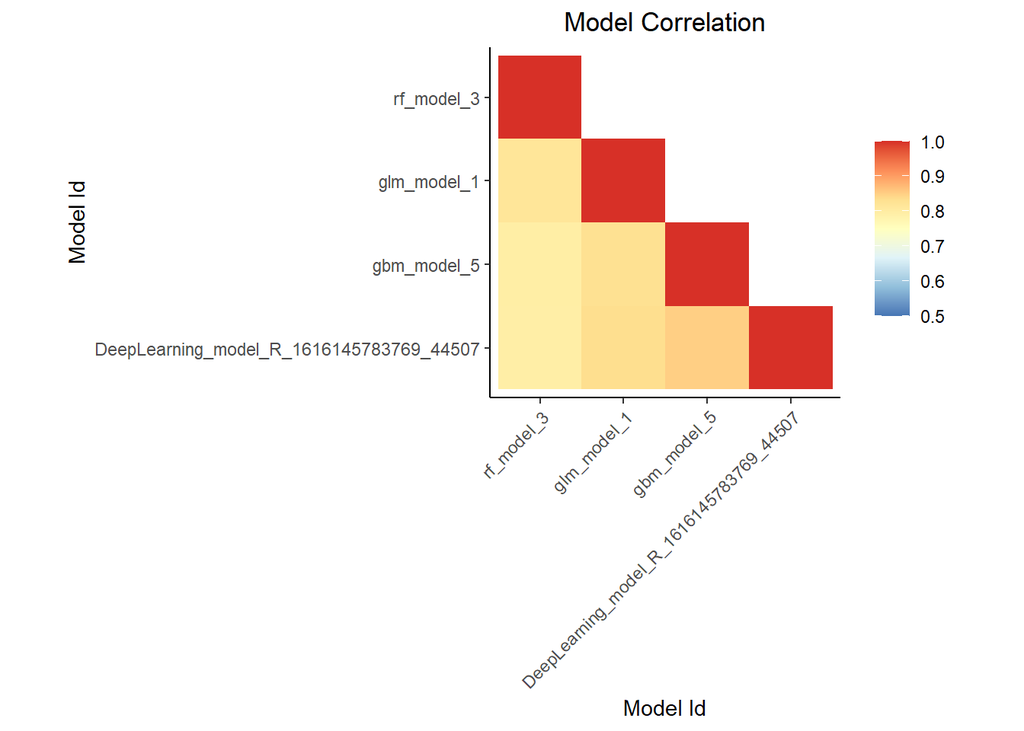

```r
# e. ----------------------------------------------------------------------

h2o.model_correlation_heatmap(my_models, data_validation)
```

The only slightly higher correlated models are the GBM and Deeplearning models. Because of this correlation and the unknown (at the time of writing this report) inner working of the deep learning model, it will not be used for the final ensemble stacked model. Only RF, GBM and Ridge will be used with an Elastic Net meta learner.

The rest appear to have a correlation of around 80% which means that we can still use them for the final ensemble predictor.

Taking a look at the variable importance heatmap across all of the models.

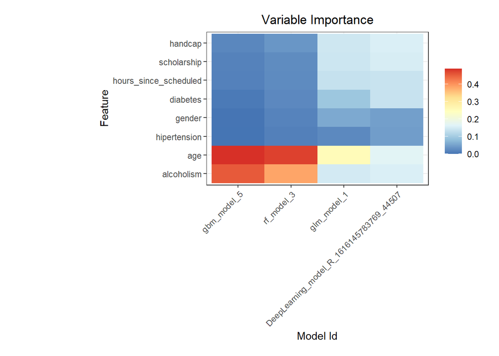

```r
h2o.varimp_heatmap(my_models)
```

## f. Create a stacked ensemble model from the base learners.

The following stacked ensemble model was built using the caret package’s function for the sake of better understanding all of the machine learning packages available in R. The same could have been done with h2o.

```r
# f. ----------------------------------------------------------------------

## Re-run data for caret package
data4 <- read_csv("https://raw.githubusercontent.com/cosmin-ticu/DS2_Ensemble-Stacking/main/data/KaggleV2-May-2016.csv")

# some data cleaning
data4 <- select(data4, -one_of(c("PatientId", "AppointmentID", "Neighbourhood"))) %>%
  janitor::clean_names()

# for binary prediction, the target variable must be a factor + generate new variables
data4 <- mutate(
  data4,
  no_show = factor(no_show, levels = c("Yes", "No")),
  handcap = ifelse(handcap > 0, 1, 0),
  across(c(gender, scholarship, hipertension, alcoholism, handcap, diabetes), factor),
  hours_since_scheduled = as.numeric(appointment_day - scheduled_day)
)

# clean up a little bit
data4 <- filter(data4, between(age, 0, 95), hours_since_scheduled >= 0) %>%
  select(-one_of(c("scheduled_day", "appointment_day", "sms_received")))

## Partition dataset again
set.seed(1234)
train_indices_temp <- as.integer(createDataPartition(data4$no_show,
                                                p = 0.5, list = FALSE))
data_temp <- data4[train_indices_temp, ]
data_test_stacking <- data4[-train_indices_temp, ]

# Further split into 10% training (5% of original) and 90% validation (45% of original)
set.seed(1234)
train_indices_final <- as.integer(createDataPartition(data_temp$no_show,
                                                p = 0.1, list = FALSE))
data_train_stacking <- data_temp[train_indices_final, ]
data_validation_stacking <- data_temp[-train_indices_final, ]

## Run Caret Ensemble models
set.seed(1234)

trctrlCaretStack <- trainControl(method = "cv",
                                 n = 5,
                                 classProbs = TRUE, # same as probability = TRUE in ranger
                                 summaryFunction = twoClassSummary,
                                 savePredictions = 'all',
                                 index=createFolds(data_train_stacking$no_show, 3))


caretModelList <- caretList(
  no_show~ .,
  data=data_train_stacking,
  trControl=trctrlCaretStack,
  metric="ROC",
  tuneList=list(
    rf=caretModelSpec(method="rf", family='binomial', tuneGrid=data.frame(.mtry=2)),
    glmnet=caretModelSpec(method="glmnet", family='binomial', tuneGrid=data.frame(.alpha=0 , .lambda=0.01)),
    gbm=caretModelSpec(method="gbm", tuneGrid=data.frame(.n.trees=500, .interaction.depth=2, .shrinkage=0.01, .n.minobsinnode=5))
  )
)
stackedCaretModel <- caretStack(
  caretModelList,
  method='glmnet', # by default
  family = "binomial",
  metric="ROC",
  tuneLength=10,
  trControl=trainControl(
    number=10,
    savePredictions="final",
    classProbs=TRUE,
    summaryFunction=twoClassSummary
  )
)
```

ROC was used to select the optimal model using the largest value. The final values used for the model were alpha = 0.2 and lambda = 0.02400909.

Plotting the stacked model across all the mixing percentage, we see:

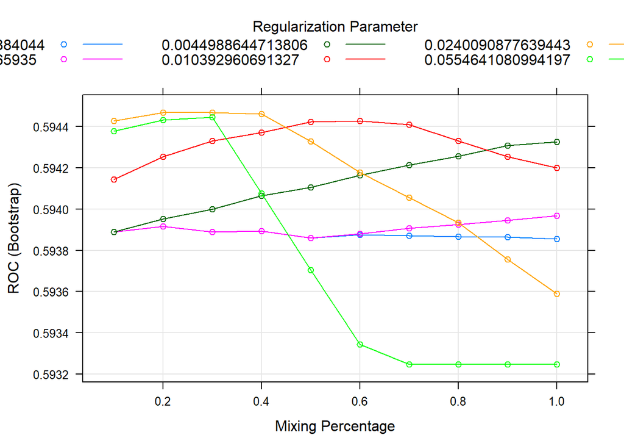

```r
plot(stackedCaretModel)
```

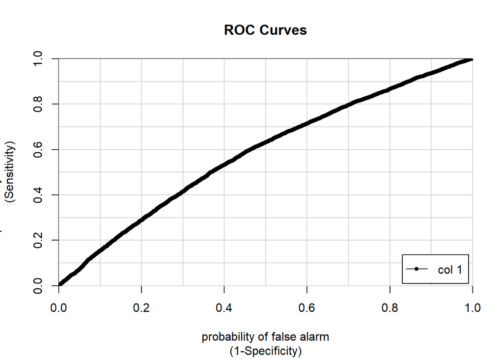

```
##                 [,1]
## Yes vs. No 0.5843401
```

```r
## ROC Plot with built-in package
stacking_pred<-predict(stackedCaretModel, data_validation_stacking, type="prob")
colAUC(stacking_pred, data_validation_stacking$no_show, plotROC = TRUE) # pretty bad but better than individual models
```

The ROC curve is still quite bad, but only very slightly better than the majority of the individual models.

## g. Evaluate ensembles on validation set. Did it improve prediction?

```r
# g. ----------------------------------------------------------------------

stackedCaretModelRoc_validation <- roc(predictor = predict(stackedCaretModel,
                                                newdata=data_validation_stacking,
                                                type='prob', decision.values=T),
                            response = data_validation_stacking$no_show)

stackedCaretModelRoc_validation$auc[1]
```

```
## [1] 0.5843401
```

```r
auc_on_validation <- auc_on_validation %>% add_row(model='stacked',AUC=stackedCaretModelRoc_validation$auc[1])

knitr::kable(auc_on_validation)
```

| model | AUC |
| --- | --- |
| rf_model_3 | 0.5719058 |
| glm_model_1 | 0.5766324 |
| DeepLearning_model_R_1616145783769_44507 | 0.5798452 |
| gbm_model_5 | 0.5845242 |
| stacked | 0.5843401 |

The stacked model has been beaten in performance by the GBM model by the smallest margin possible, a 0.02% difference in AUC.

For the sake of this assignment, the final model to be evaluated on the test set will be the stacked ensemble model.

## h. Evaluate the best performing model on the test set. How does performance compare to that of the validation set?

```r
# h. ----------------------------------------------------------------------

stackedCaretModelRoc_test <- roc(predictor = predict(stackedCaretModel,
                                                           newdata=data_test_stacking,
                                                           type='prob', decision.values=T),
                                       response = data_test_stacking$no_show)

stackedCaretModelRoc_test$auc[1]
```

```
## [1] 0.5873686
```

Due to having a test set that is a little larger than the validation set, we see a slight increase in AUC from the validation (0.5843401) to the test (0.5873686). Nonetheless, the Area Under the Curve of our model is not even 60%, thus not being far better performing than just a fair coin flip.